# Session 1 — Marketing Research Process & Getting Started with R

M731 Week 1 · September 9, 2026

Shay Abbasi

2026-09-09

## Welcome to M731

Marketing Research at DeGroote

## Today’s agenda

1. Course logistics
2. Introduction to marketing research
3. The marketing research process
4. Our running case: Maritime Roast Coffee Co.
5. **Break (15 min)**
6. Getting started with R, RStudio, and Quarto
7. Live-code: Chapman & Feit Chapter 2
8. Ethics thread + industry context
9. Wrap-up + Week 2 preview

## Learning objectives for today

By the end of session 1 you will be able to:

- Locate marketing research within the broader marketing decision process
- Walk through the marketing research process end-to-end
- Set up a working R + RStudio + Quarto environment
- Render a first `.qmd` report from a real dataset
- Learn bout PIPEDA and TCPS-2 CORE ethics certification

# Part 1 — Course logistics

## Who and where

- **Instructor.** Shay Abbasi · `abbass44@mcmaster.ca`
- **TA.** Ms. Saba Khorasani · `sabaakhr@mcmaster.ca`
- **Where.** RJC 236 (Burlington campus), Wednesdays, 3 hours
- **Office hours.** Zoom, by appointment (book by email)
- **Course site.** Avenue to Learn (“BUSADMIN M731: Marketing Research”)

## Prerequisites (checked at registration)

- **M650** (or equivalent) — statistics / quantitative methods
- **I602** (or equivalent) — introductory quantitative methods

We will review and learn more about statistical tests such as t-tests, chi-square, or basic regression as we go.

## Course structure at a glance

- **13 weeks**: 12 lecture weeks + 1 presentation week
- **All materials as HTML files & Quatro Files** — you’ll be reading, writing, and rendering these
- **A running case** (Maritime Roast Coffee Co.) threads every week

## Assessment (100%)

| Component | Weight | When |
| --- | --- | --- |
| Assignment 1 (individual) | 10% | Due Wk 6 |
| Assignment 2 (individual) | 10% | Due Wk 9 |
| Test 1 (covers Lectures 1-4) | 20% | Wk 5 |
| Test 2 (covers Lectures 5-10) | 20% | Wk 11 |
| Project proposal + questionnaire (grp) | 10% | Due Wk 4 & 9 |
| Written report (group) | 20% | Due Wk 13 |
| Presentation (group) | 10% | Wk 13 |
| **Total** | **100%** | **No final exam** |

## Group project overview

- **Groups of 5-6** — we’ll form these by end of Week 2
- **Company of your choice** (A B2C Canadian Business)
- **Three deliverables:** proposal (Wk 4) + questionnaire (Wk 9), written report (Wk 13), presentation (Wk 13)
- If you have preferences for teammates, send them to the TA by **Sep 11 EOD**
  - In the email mention names and student numbers

## Generative AI policy

- Generative AI (ChatGPT, Claude, Copilot, etc.) is **allowed** for:
  - Learning course material
  - Studying for tests
  - Explaining error messages
- Generative AI is **prohibited** for graded assessments:
  - Tests
  - Any part of the group project (except as an explicitly disclosed learning aid)

## Tests and missed work

- **Tests:** Multiple choice and/or written. Sample questions will be provided beforehand.
- **Missed test:** Do NOT use MSAF (MBA program doesn’t accept it). Documented reasons via DSSAO within 5 working days.
- **SAS accommodations:** Coordinate via `DSBSAS@mcmaster.ca` at least two weeks before each test.

## Attendance & Class Participation

- **Attendance matters** — you’ll get more out of the course by being present
- **Class Participation**: Still not evaluated, but valuable to me personally.

## What is Marketing?

> Marketing is the activity, set of institutions, and processes for **creating, communicating, delivering, and exchanging offerings** that have value for customers, clients, partners, and society at large.

> — American Marketing Association (2007)

Note the four levers: **creating, communicating, delivering, and exchanging** — this is the marketing mix, and it’s the frame for everything that follows.

## Marketing management philosophies

Five philosophies describe how an organisation decides *what* to produce and sell:

| Philosophy | Core belief | Managerial focus |
| --- | --- | --- |
| **Production Concept** | Consumers prefer products that are widely available and inexpensive | Production efficiency, low cost, mass distribution |
| **Product Concept** | Consumers favour products offering the best quality, performance, features | Continuous product improvement and innovation |
| **Selling Concept** | Consumers won’t buy enough unless the firm sells and promotes aggressively | Aggressive selling and promotion |
| **Marketing Concept** | Achieving organisational goals depends on knowing target-market needs and delivering value better than competitors | Customer needs first, integrated marketing effort |
| **Societal Marketing Concept** | Marketing decisions should balance company profits, consumer wants, and society’s long-run well-being | Consumer welfare + societal interest alongside profit |

*Source: adapted from Kotler, P., & Keller, K. L., Marketing Management.*

## The Marketing Concept: three orientations

The **Marketing Concept** (previous slide) isn’t just an attitude — it shows up as three concrete orientations inside a market-oriented organisation:

- **Consumer orientation** — understand and respond to customer needs
  - MR — Uncovers unarticulated pain points rather than relying on internal assumptions.
  - MR — Identifies viable sub-segments and buyer personas based on behaviors rather than crude demographics.
  - MR — Tests concept feasibility, usability, and willingness-to-pay before capital commitment.
  - Exmple: Lego 2000s observational research on boys vs. girls playing behavior
    - **What do you think about this?**

## Consumer orientation: customer focus & market intelligence

- **Customer focus** — continuously understand and respond to customer needs, through feedback loops, responsive service, and regular engagement
- **Market intelligence** — actively collect and analyse information on customers, competitors, and the broader market (competitive analysis, trend monitoring, ongoing research)
- **Distributing intelligence** — insight only matters if it’s shared: cross-functional teams, shared dashboards, regular briefings
- Together, these help the organisation spot opportunities, anticipate demand shifts, and stay ahead of competitors

## System orientation: coordinated marketing & responsiveness

- **Coordinated marketing** — every department works together to create, communicate, and deliver value consistently, via integrated marketing communications and cross-functional collaboration, so the customer gets one unified experience
- **Responsiveness** — the ability to adapt quickly when customer needs or market conditions change (agile marketing, rapid prototyping)
- Both require clear communication, shared goals, and a willingness to change course when the data says so

## Goal orientation: profitability & long-term perspective

Customer satisfaction is the priority, but it has to be **sustainable**:

- **Profitability** — satisfying customers is the goal, but the organisation still needs to be financially viable; customer lifetime value (CLV) and return on marketing investment (ROMI) measure whether customer-focused efforts pay off
- **Long-term perspective** — the focus is on building lasting relationships, not maximising next quarter’s numbers (loyalty programs, strategic partnerships)
- Sometimes this means short-term sacrifices (e.g., investing in service improvements that don’t immediately lift revenue) in exchange for sustainable growth

# Part 2 — What is marketing research?

## Marketing research, defined

> Marketing research is **the systematic gathering, recording, and analysis of data** about problems relating to the marketing of goods and services.

> — American Marketing Association

Three words matter: **systematic**, **data**, **problems**.

## Marketing Reseaarch New Definition

Marketing research is the function that links the consumer, customer, and public to the marketer through information—information used to identify and define opportunities and problems; generate, refine, and evaluate actions; monitor performance; and improve understanding of it as a process. It specifies the information required to address these issues, designs the method for collecting information, manages and implements the data collection process, analyzes the results, and communicates the findings and their implications. (AMA 2017)

## Marketing Research Vs. Marketing Analytics

Marketing Research vs. Marketing Analytics

| Dimension | Marketing Research | Marketing Analytics |
| --- | --- | --- |
| **Trigger** | A specific business question or decision problem | Continuous operational data and recurring metrics |
| **Primary Focus** | The market and customer (needs, perceptions, behavior) | The marketing system (channel efficiency, spend, attribution) |
| **Data Strategy** | Purpose-built: primary studies (surveys, experiments) + external secondary sources | Always-on: internal operational logs, CRM, web events, and ad pipelines |
| **Cadence** | Project-based (defined beginning, brief, and final report) | Continuous (real-time dashboards, recurring model runs) |
| **Causal Approach** | Prospective design: lab tests, field trials, test markets | Retrospective modeling & platform tests: econometrics, MMM, live A/B tests |
| **End Deliverable** | Recommendations and strategic insight for managers | Dashboards, predictive models, and automated optimization tools |

## Marketing research vs. market research

- **Market research:** studying a specific market (size, structure, competitors)
- **Marketing research:** studying anything that informs marketing decisions — pricing, product, promotion, place, plus customer research, brand research, etc.

The terms are often used interchangeably. This course covers the broader “marketing research.”

## Where does MR sit in an organisation?

- **Client-side:** In-house Insights team at a brand (Loblaws, Bell, TD)
- **Supplier-side:** MR agencies (Nielsen, IRI/Circana, Ipsos, Environics)
- **Consulting:** Strategy firms with insights practices (McKinsey, BCG)

## Why/when we need MR?

- **Managers’ judgement may be biased.**
- **Resources are scarce.**
- **Not all opportunities and problems visible**
- **Rapid Macro & Environmental Shifts**
- **High Cost of Reversibility (Asymmetrical Downside)**
- **Geographic & Cultural Expansion**
- **Internal Gridlock**: Different departments have conflicting opinions.
- What other situations can you name?

## What questions does MR answer?

- **Descriptive:** Who buys, what they buy, when, how much?
- **Diagnostic:** Why did share drop? Why are customers churning?
- **Predictive:** Will this new product succeed? What is the price elasticity?
- **Prescriptive:** Which segment should we target? What should the pack say?

Every research project should answer at least one of these — clearly.

## Research Problems ~ Questions

- **Jobs to Be Done (JTBD) framework**
- How prescriptive questions for a sales problem became diagnostic questions?!

## The four Ps and MR

MR informs each of the marketing mix decisions:

- **Product:** concept tests, product-in-use tests, package tests
- **Price:** price sensitivity, willingness-to-pay, van Westendorp
- **Place:** channel performance, distribution audits
- **Promotion:** ad tests, brand tracking, media effectiveness

Plus: segmentation, positioning, brand equity, customer satisfaction.

## MR & Product

- **Concept Tests**:
  - Does this idea solve a real problem? Is there purchase intent?
  - Which proposed features resonate most, and which confuse people?
- **Product-in-Use Tests (Home-Use Tests / IHUTs)**:
  - How does the product perform under real-world conditions?
  - Does it deliver on its promised benefits?
  - Are there unforeseen usability flaws, unpleasant textures, bugs, or taste fatigue?
- **Package Tests**:
  - Does the package grab attention on a crowded store shelf?
  - Does it communicate essential claims quickly?
  - Is it easy to open, hold, dispense, and store?

## MR & Price

- **Price elsticity of demand**
  - At what point does a price increase reduce overall unit demand so much that total revenue or gross margin drops?
- **Willingness-to-Pay (WTP)**:
  - What is the hypothetical price ceiling for our offering?
  - Which specific customer sub-segments perceive enough differentiated value to pay a premium?
- **Van Westendorp Price Sensitivity Meter (PSM)**:
  - A four-question survey methodology asking respondents at what exact price points a product becomes: (1) Too cheap (questionable quality), (2) A bargain, (3) Getting expensive (requires thought), and (4) Too expensive (unacceptable).

## Van Westendorp Price Sensitivity Meter

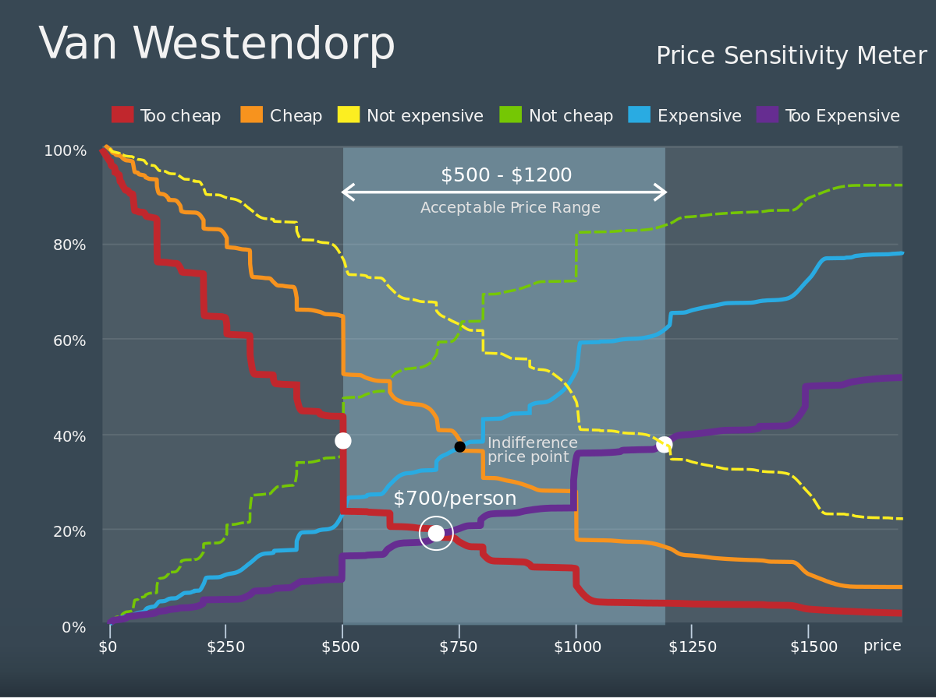

Figure 1: Van Westendorp Price Sensitivity Meter Analysis, Source: Wikipedia

## MR & PSM connect to Pricing Strategies

Interpretation of Van Westendorp Price Sensitivity Intercepts

| Price Benchmark | Intersection Lines | Chart Value | Strategic Implication |
| --- | --- | --- | --- |
| **Point of Marginal Cheapness (PMC)** | *Too Cheap* $\cap$ *Not Cheap* | **$500** | **Lower Bound / Quality Risk:** Pricing below this risks negative perceptions of quality, safety, or reliability. |
| **Optimal Price Point (OPP)** | *Too Cheap* $\cap$ *Too Expensive* | **$700** | **Volume Maximization:** Minimizes aggregate consumer resistance; best for rapid market adoption and penetration. |
| **Indifference Price Point (IDP)** | *Cheap (Bargain)* $\cap$ *Expensive* | **$750** | **Neutral Equilibrium:** Equal proportion perceive it as a bargain vs. expensive; represents the typical reference price. |
| **Point of Marginal Expensiveness (PME)** | *Too Expensive* $\cap$ *Not Expensive* | **$1,200** | **Upper Bound / Churn Risk:** Pricing above this triggers severe purchase drop-off as perceived cost exceeds perceived value. |
| **Acceptable Price Range** | Span between PMC and PME | **$500 – $1,200** | **Feasible Window:** The pricing corridor where the product is viable without extreme quality doubt or price rejection. |

## MR & Place (Distribution)

- **Channel Performance**:
  - Where are customers abandoning the buying journey?
- **Distribution Audits**
  - Are retailers honoring negotiated shelf space, facings, endcap promotions, and planograms?
  - Are our SKUs in stock or suffering out-of-stock losses?

## MR & Promotion

- **Ad Tests (Pre-testing & Copy Testing)**:
  - Does the ad break through the noise?
  - Do viewers clearly associate the ad with the correct brand (avoiding “vampire creativity”)?
  - Does it provoke the desired emotion or lift purchase intent?

## Quick check: descriptive, diagnostic, predictive, or prescriptive?

What type of question are we asking?

## Example 1 — Product

> “How many subscribers have tried the Discovery tier since launch?”

**Descriptive** — counting who did what, how much.

## Example 2 — Product

> “Why are Discovery-tier subscribers cancelling within their first two months?”

**Diagnostic** — explaining a problem (early churn).

## Example 3 — Product

> “If we add a decaf option to the Discovery tier, how many current subscribers would upgrade?”

**Predictive** — forecasting the effect of a product change.

## Example 4 — Product

> “Which new roast should we add to the Discovery tier lineup?”

**Prescriptive** — recommending a specific action.

# Part 3 — The marketing research process

1. **Define the Problem**
2. **Develop Research Plan** (exploratory, descriptive, causal)
3. **Collect Data**
4. **Analyze Data**
5. **Report the Findings**
6. **Take Action**

Every session in this course corresponds to a step (or part of one).

## Step 1: Define the Problem (the hard step)

The **business problem** ≠ the **research problem**.

- Business problem: “Our subscription churn is up 3 pp.”
- Research problem: “Identify the leading drivers of 6-month churn, and quantify the impact of each and provide remedies.”

The research problem is **specific, measurable, and answerable with data**.

## Step 2: Develop Research Plan - Research design

Three families:

- **Exploratory:** hypotheses unclear, need to understand the phenomenon → qualitative, secondary data
  - Exp: What drives churn?
- **Descriptive:** you know the questions, need to quantify → surveys, panel data
  - Exp: What is the main driver of churn among these?
- **Causal:** need to know if X causes Y → experiments, quasi-experiments
  - Exp: Is location really the driver of churn?

Most projects are descriptive. All three families are on our syllabus.

## Step 3: Collect Data

- **Frame:** who is eligible to be in the sample? Does the sample represent population?
- **Method:** probability (random) or non-probability (convenience, quota)?
- **Size:** how many? (calculated from precision and effect size)

Not: “we’ll get 400 responses.” Yes: “we’ll get 400 responses because that gives us ±5% precision at 95% confidence for a proportion around 50%.”

## Step 3: Collect Data: Instruments

- **Surveys** use questionnaires (Wk 4, refined in Wk 8)
- **Focus groups** use discussion guides (Wk 5)
- **Observational studies** use coding protocols (Wk 5)
- **Experiments** use treatment scripts (Wk 10)

Instruments are where measurement error sneaks in — bad wording, bad order, leading questions.

## Step 3: Collect Data — Primary vs. Secondary Data

**Primary data** — collected firsthand, for *this* research question:

- Surveys · Focus Groups · Observational Studies · Experiments
- These are our four instruments from the previous slide

**Secondary data** — already collected, for *some other* purpose, that we repurpose:

- Internal Secondary Data
- Government & Public Data
- Syndicated / Commercial Data Services
- Trade, Industry & Academic Publications

Rule of thumb: **check secondary data first** — it’s cheaper and faster than commissioning new primary research.

## Surveys (Questionnaires)

- **How:** a structured set of questions administered to a sample — online panel, phone, mail, or in-person intercept
- **What they have:** closed- and open-ended questions, Likert/rating scales, skip logic, demographic classification items
- **Purpose:** quantify attitudes, behaviours, and awareness at scale; test hypotheses; track change over time

**Pros**

- Large samples, statistically generalisable
- Relatively low cost per respondent
- Easy to replicate and track over time

**Cons**

- Social-desirability / response bias
- Low response rates
- Limited depth on *why*

## Focus Groups

- **How:** 6–10 participants, moderator-led discussion, 60–90 minutes, often with client observation
- **What they have:** a discussion guide, warm-up + core topics + projective exercises, audio/video recording and transcript
- **Purpose:** explore attitudes and reactions in depth; generate hypotheses; pre-test concepts or ads

**Pros**

- Rich qualitative insight
- Group dynamic surfaces reactions
- Relatively fast to field

**Cons**

- Not statistically generalisable
- Dominant participants skew discussion
- Groupthink / social desirability

## Observational Studies

- **How:** a researcher (or camera/sensor) watches and records actual behaviour in a real or simulated setting, using a coding protocol
- **What they have:** a structured coding sheet, behavioural counts/timings, sometimes video or eye-tracking data
- **Purpose:** capture what people actually *do*, rather than what they *say* they do

**Pros**

- No self-report or recall bias
- Captures context and unconscious behaviour
- High validity for behavioural questions

**Cons**

- Can’t directly observe motivations or attitudes
- Observer effect (people act differently when watched)
- Time- and labour-intensive; hard to generalise from a small sample

## Experiments

- **How:** the researcher manipulates one variable (the treatment) while controlling others, randomly assigning subjects to treatment vs. control, using a treatment script
- **What they have:** random assignment, treatment vs. control conditions, pre/post or between-subjects measurement
- **Purpose:** establish **causality** — does X actually cause Y? (e.g., does a price change cause a change in demand?)

**Pros**

- Strongest method for causal claims
- Controls for confounding variables
- Replicable

**Cons**

- Artificial settings may lack external validity
- Expensive and slow to field properly
- Ethical/practical limits on what can be manipulated

## Internal Secondary Data

- **How:** data your own organisation already collects and stores for operational purposes
- **What they have:** sales records, CRM/loyalty data, transaction histories, past research reports, financial data, website/app analytics
- **Purpose:** understand your own customers and performance *before* spending on new primary research; establish a baseline

**Pros**

- Free or near-free — already paid for
- Fast to access
- Directly relevant to your business, often large volume

**Cons**

- May not answer new, forward-looking questions
- Data quality/format inconsistent across systems
- Privacy/access restrictions; no competitor or market view

## Government & Public Data

- **How:** published by government statistical agencies and public bodies (e.g., Statistics Canada, Census, municipal open-data portals)
- **What they have:** demographic, economic, industry, and household-spending data; census counts; regional/provincial breakdowns
- **Purpose:** size a market, profile a target population, benchmark against national or regional trends

**Pros**

- Free
- Authoritative and credible
- Broad geographic and demographic coverage

**Cons**

- Often lags real time (published with a delay)
- Not company- or brand-specific
- May not break down to the exact segment you need

## Syndicated / Commercial Data Services

- **How:** purchased from specialist research firms (e.g., Nielsen, IRI/Circana, Ipsos) who collect data once and sell access to many subscribing clients
- **What they have:** retail sales/scanner data, media audience/ratings data, brand-tracking panels, household purchase panels
- **Purpose:** benchmark market share, track category trends, compare your brand against competitors continuously

**Pros**

- Much cheaper than commissioning the same scale yourself
- Continuously updated/tracked over time
- Covers the whole category, including competitors

**Cons**

- Subscription cost can still be substantial
- Not customised to your specific research question
- Available to your competitors too — no exclusivity

## Trade, Industry & Academic Publications

- **How:** reports and articles published by trade associations, industry analysts, consultancies, and academic journals
- **What they have:** industry trend analysis, competitor profiles, expert commentary, peer-reviewed theory and findings
- **Purpose:** understand industry structure and the competitive landscape, and ground new research in established theory

**Pros**

- Often free or low-cost
- Provides context and credibility (citable)
- Synthesises many sources already

**Cons**

- May be biased toward the publishing organisation’s interests
- Can be generic, not company-specific
- Academic sources can lag current market conditions

## Step 3: Collect Data — Fielding Primary Data

- **Modes:** in-person, phone, mail, online, mobile, panel
- **Trade-offs:** cost, speed, coverage, response bias, incidence rate
- **Quality:** attention checks, straight-lining detection, IP dedup

For your group project, you use **primary data** and you should be able to design a collection plan for fielding.

## Step 4: Analyze Data

- **Explore and Describe** the data (Wk1 - Wk 6)
- **Test** hypotheses (Wks 6-7)
- **Reduce** complexity (Wks 8 scales, 9 factor)
- **Design experiments** (Wk 10)
- **Model** drivers (Wk 11 regression)

R is our tool for every one of these. That’s why we start setting up R today.

## Step 5: Report the Findings

- **Structure:** executive summary → findings → evidence → limitations → recommendations
- **Audience:** the decision-maker, not the analyst
- **Format:** Quarto, HTML for reading, PDF for archiving, slides for presenting

## Step 6: Take Action

The best analysis in the world is worthless if the recommendation doesn’t land. Wk 12 covers reporting.

# Part 4 — The running case: Maritime Roast Coffee Co.

## Meet Maritime Roast

- Halifax-based direct-to-consumer specialty coffee subscription
- Founded 2019, ~15,000 subscribers
- Small retail presence across Atlantic Canada (independent grocer partnerships)
- Three subscription tiers: **Standard, Signature, Discovery**

*(Fictional company - but based loosely on real Canadian coffee subscription businesses.)*

## The decisions on Maritime Roast’s plate

Every technique this term is motivated by one of these decisions.

## What the case gives us

- **A recurring dataset spine** — `maritime_survey.csv`, `maritime_transactions.csv`
- **A worked example every week** — see how one company applies each technique
- **A template for your project** — you’ll do the equivalent for your chosen company

The group project uses a **different** company (Maritime Roast is the teacher’s example).

## Break — 15 minutes

Meanwhile: install R (`https://cran.rstudio.com/`) and RStudio (`https://posit.co/download/rstudio-desktop/`) if you haven’t yet. Download maritime_transactions.csv from A2L

# Part 5 — Getting started with R, RStudio, Quarto

## What are we installing?

- **R** — the language and statistical engine (`https://cran.rstudio.com/`)
- **RStudio (Posit)** — the IDE we’ll use to write R code (`https://posit.co/download/`)
- **Quarto** — the publishing system we’ll use for all documents (`https://quarto.org`)
- **TinyTeX** — a lightweight LaTeX install so we can render to PDF (`quarto install tinytex`)

Everything is free and cross-platform.

## RStudio anatomy

- **Top-left:** editor pane (where you write .qmd and .R files)
- **Bottom-left:** console (where R evaluates commands)
- **Top-right:** environment (variables, data frames)
- **Bottom-right:** files, plots, packages, help

## Anatomy of a .qmd file

````
---
title: "My first Quarto document"
format: html
---

# A section header

Some prose.


::: {.cell}

```{.r .cell-code}
1 + 1
```
:::
````

Three parts: **YAML header** (metadata), **prose** (markdown), **code chunks** (R).

## Installing packages

```r
install.packages(c(
  "tidyverse", "readr", "readxl", "haven", "jsonlite",
  "knitr", "gt", "kableExtra", "janitor", "broom",
  "renv", "psych", "car", "lmtest", "sandwich",
  "effectsize", "pwr", "corrplot", "emmeans", "lm.beta",
  "tidytext", "readtext", "MASS", "RColorBrewer"
))
```

Run this **once** during the lab. Takes 5-10 minutes.

## The `renv` reproducibility promise

```r
renv::init()      # first time: creates project-level package library
renv::snapshot()  # before submitting: lock package versions
renv::restore()   # someone else opens the project: restore the lock
```

Every group project must include a working `renv.lock` file.

# Part 6 — Live-code: CF Chapter 2

## What we’ll cover in the lab

- Vectors, data frames, indexing
- Reading a CSV file
- Basic descriptive statistics
- Your first Quarto render

Working dataset: `maritime_transactions.csv` (~15,000 rows).

## Vectors

```r
prices <- c(15.99, 22.50, 18.75, 25.00, 19.99)
mean(prices)
sd(prices)
median(prices)
```

A vector is a sequence of values of the same type.

## Data frames

```r
library(tidyverse)
tx <- read_csv("data/maritime_transactions.csv")
glimpse(tx)
dim(tx)
```

A data frame is a table where each column is a vector of the same length.

## Indexing

```r
tx$tier            # one column
tx[1, ]            # first row
tx[1:5, "amount"]  # first five values of the amount column

tx |> filter(tier == "Discovery") |> summarise(mean_amount = mean(amount))
```

The pipe `|>` reads left-to-right, “and then”.

## Descriptives with dplyr

```r
tx |>
  group_by(tier, region) |>
  summarise(
    n = n(),
    mean_amount = mean(amount),
    median_amount = median(amount),
    total = sum(amount)
  )
```

Read this as: “take tx, group by tier and region, then compute these summaries per group.”

## Full worked solution

The in-class snippets above are the live-coding version.

**`session-01-RLab.qmd`** in this session’s folder is the full teaching companion: RStudio and Quarto basics, R data types, reading data, deriving variables, cleaning real data-quality problems (messy labels, duplicates, outliers, missing values), descriptive statistics, and a full set of `ggplot2` visualisations — all run against the same `maritime_transactions.csv`, with output and interpretation at every step.

## Your first Quarto render

```r
# In RStudio: File > New File > Quarto Document
# Save as: `session-01-lab.qmd`
# Click "Render" button (or Ctrl/Cmd + Shift + K)
```

You should see:

- HTML file rendered in the Viewer pane
- File saved next to your .qmd
- Any errors shown in the Render tab

## Before next week

- **Not graded**, but essential: verify your R/RStudio/Quarto setup works
- Render the lab .qmd on your own machine before Wk 2
- Post any install errors in the A2L discussion so we can debug collectively

# Part 7 — Ethics thread

## Why ethics is a course thread, not a lecture

- Every session has an ethics moment (10-15 min) baked in
- Because ethics isn’t a topic - it’s a way of doing research
- We don’t wait until the ethics lecture to worry about consent

## Governing Bodies on Information

- **For Gov. funded project**
  - **Tri-Council Policy Statement, 2nd edition, CORE tutorial**
  - Free, online, ~2 hours
  - Register at `https://tcps2core.ca`
- **For Companies**
  - PIPEDA

## PIPEDA in a marketing-research context

- **Personal Information Protection and Electronic Documents Act** (Canadian federal)
- Applies whenever you collect / use / disclose personal information for commercial purposes
- Governs: consent, purpose limitation, retention, security, individual access
- Even secondary data - if it identifies people, PIPEDA applies

# Part 8 — Industry context

## What an MR analyst actually does

Typical workflow at a client-side Insights team:

1. **Brief in** (from marketing manager or product team)
2. **Scope the study** (design, sample, budget, timeline)
3. **Field** (in-house or via supplier)
4. **Analyse** (in R, SPSS, Q, or Excel-plus-tears)
5. **Report** (deck for stakeholders + one-page executive summary)
6. **Follow up** (dashboards, tracking, next research question)

## Two industries in one profession

- **Client-side.** Insights function inside a brand — mainly consumers of MR + occasional in-house studies
- **Supplier-side.** MR agencies — design, field, analyse, and deliver studies for clients

Career paths differ. Client-side rewards domain expertise; supplier-side rewards methodological range.

## Professional bodies

- **ESOMAR** (global, EU-centred): `www.esomar.org`
- **Insights Association** (US): `www.insightsassociation.org`
- **MRIA-ARIM** (Canada): `www.mria-arim.ca`

Codes of conduct, career resources, conferences, mentorship.

# Part 9 — For your project

## Team formation begins today

- Talk to your classmates
- If you have group preferences, emil them to the TA by Friday EOD
- I’ll finalise teams by next Monday

If you don’t have a preference, I’ll assign you.

## What to think about for your project

- What **decision** would you like to inform?
- Whose decision is it? (Real or plausible client)
- What data would you need? Is secondary data available?
- Rough timeline of what you’ll design vs. analyse

Don’t pick a topic yet. Just start noticing decisions in the world that could use research.

# Part 10 — Wrap-up & Week 2 preview

## What we did today

- Located marketing research in the marketing decision process
- Walked through the MR process
- Met Maritime Roast, our running case
- Installed R, RStudio, Quarto; rendered our first `.qmd`
- Talked about ethics and privacy
- Started team formation

## Next week: Secondary data and research designs

- **Concept:** where to find secondary data, when to trust it, choosing among exploratory / descriptive / causal designs
- **R lab:** data visualisation with ggplot2

Come prepared: R environment working

## References

Silver, L., Stevens, R., Wrenn, B., & Loudon, D. (2021). The essentials of marketing research. SAGE Publications.

## Thank you — see you next Wednesday

Questions? Reach me at **abbass44@mcmaster.ca** or book office hours.